# (Effects of Loans Characteristics on Borrower's APR)

## by (Mohammad Aamir)

## Investigation Overview

> In this investigation, I wanted to look at the characteristics of loan that could be used to predict their borrower APR. The main focus was on borrower prosper rating, original loan ammount and Term.

## Dataset Overview

> The prosper loan data set contains 83982 complete loan data for all loans issued through the 2007–2011, it contains 15 variables. Each row contains information on a loan, including loan amount, BorrowerAPR, borrower rate, Term, borrower income, Investors, and more. 14793 data points were removed from the analysis due to inconsistencies or missing information.

## (Distribution of Borrower APR)

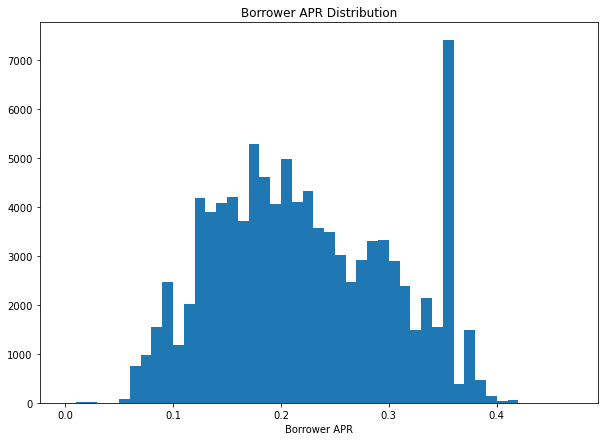

## (Borrower APR vs. Prosper Rating)

> The borrower APR decreases with the increasingly better rating. Borrowers with the best Prosper ratings have the lowest APR. It means that the Prosper rating has a strong effect on borrower APR.

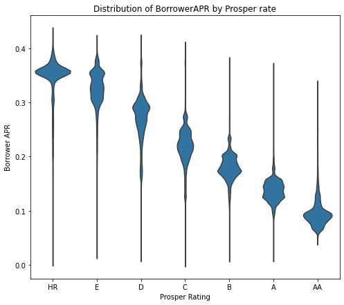

## (Borrower APR vs. Loan Original Amount)

> Negative correlation between LoanOriginalAmount and BrowerAPR, that is the more the loan amount, the lower the APR.

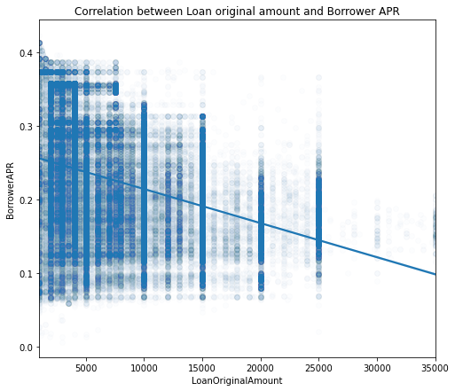

## (Borrower APR by Prosper rating and Term)

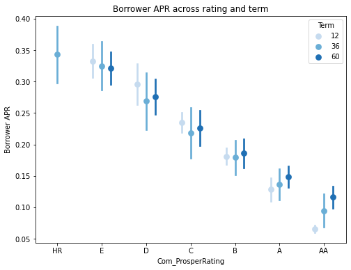